# climplot: Facilitate and tailor Walter & Lieth climatic diagram construction

[Auman Chan, PhD Candidate](https://gitee.com/auman-chan)

2023-07-23

[figure not shown]

climplot aims to collect crucial climate data for global locations and construct the Walter & Lieth climatic diagrams in a more user-friendly and personalized manner.

The main features of the package are:

- The use of worldwide climate data to obtain standardized and reliable data for constructing Walter & Lieth climatic diagrams
- The provision for more parameter to customize the plots and display comprehensive information

The package offers functions for:

- Obtain climate data to construct Walter & Lieth Climatic Diagram for global locations
- Construct the Walter & Lieth climatic diagram
- Revise the color scheme and information presentation of the diagram

# Installing and loading

To install the latest developmental version from [github](https://github.com/) and [gitee](https://gitee.com/), you will need the R package remotesand git2r. If you want to see more help of this package, please add `build_vignettes= TRUE`.

```r
install.packages('remotes')

#from github
remotes::install_github("auman-chan/climplot")
#from gitee
install.packages('git2r')
remotes::install_git("https://gitee.com/auman-chan/climplot.git")

#add vignettes
remotes::install_github("auman-chan/climplot",build_vignettes= TRUE)

remotes::install_git("https://gitee.com/auman-chan/climplot.git",
                     build_vignettes= TRUE)

#add vignettes
remotes::install_github("auman-chan/climplot",build_vignettes= TRUE)

remotes::install_git("https://gitee.com/auman-chan/climplot.git",
                     build_vignettes= TRUE)
```

# Plotting data extraction

The task of searching for and processing climate data from multiple locations is a challenging endeavor. Function `clim_extract` can retrieve data derived from Worldclim Historical monthly weather data in 2010-2019(Version of 2.5 minutes, https://worldclim.org/data/monthlywth.html), which be ready for diagrams visualization.

## Data preparation

### Climate data download

The climate data provided by Worldclim is indispensable, however, due to its global-scale raster layer format, the file size are substantial and cannot be accommodated within the package. Therefore, kindly obtain the climate dataset from Figshare before use.

The dataset comprises of four folders and a total of 48 .tif files, which include annual average minimum temperature, annual average maximum temperature, annual average precipitation, and annual extreme minimum temperature. These values are calculated by taking the monthly averages and minimizations within 2010-2019. The structure of the dataset is illustrated in the table below:

| X | annual_average_maximum_temperature | annual_average_minimum_temperature | annual_average_precipitation | annual_extreme_minimum_temperature |
| --- | --- | --- | --- | --- |
| 1 | tmax_01.tif | tmin_01.tif | prec_01.tif | extmin_01.tif |
| 2 | tmax_02.tif | tmin_02.tif | prec_02.tif | extmin_02.tif |
| 3 | tmax_03.tif | tmin_03.tif | prec_03.tif | extmin_03.tif |
| 4 | tmax_04.tif | tmin_04.tif | prec_04.tif | extmin_04.tif |
| 5 | tmax_05.tif | tmin_05.tif | prec_05.tif | extmin_05.tif |
| 6 | tmax_06.tif | tmin_06.tif | prec_06.tif | extmin_06.tif |
| 7 | tmax_07.tif | tmin_07.tif | prec_07.tif | extmin_07.tif |
| 8 | tmax_08.tif | tmin_08.tif | prec_08.tif | extmin_08.tif |
| 9 | tmax_09.tif | tmin_09.tif | prec_09.tif | extmin_09.tif |
| 10 | tmax_10.tif | tmin_10.tif | prec_10.tif | extmin_10.tif |

[output cut: 2 more lines]

### Location information preparation

In order to extract climate data for specific locations, precise coordinates are essential. Additionally, the diagram should display other relevant information such as location names and altitudes. Therefore, a data.frame containing information of the target locations is necessary for `clim_extract`. The imported data.frame must contain five columns in the following order:

- **No**: Serial number of the locations
- **location**: Abbreviation of the locations
- **lon**: Longitude of the locations in decimal digit (negative numbers indicating west longitude)
- **lat**: Latitude of the locations in decimal digit (negative numbers indicating south latitude)
- **altitude**: Altitude of the locations

The data `locdata` in this package can be a example of the import data.frame. Other extra columns with information is allowed behind the columns above, but would be discarded in following process.

| No | location | lon | lat | altitude | name |
| --- | --- | --- | --- | --- | --- |
| 1 | Motuo | 95.3536 | 29.30420 | 2025 | 墨脱县仁钦崩寺 |
| 2 | Wulianshan | 100.5000 | 24.50000 | 1301 | 无量山自然保护区 |
| 3 | Wawushan | 102.9167 | 29.50000 | 2082 | 四川省眉山市洪雅县瓦屋山 |
| 4 | Leibo | 103.4667 | 28.45000 | 1204 | 四川省凉山州雷波县 |
| 5 | Longcanggou | 102.8333 | 29.61667 | 1764 | 四川省雅安市荥经县龙苍沟国家森林公园 |
| 6 | Jinfoshan | 107.1933 | 29.00017 | 1917 | 重庆市南川区金佛山国家级自然保护区 |
| 7 | Xishui | 106.4667 | 28.30000 | 863 | 贵州省习水良村镇羊化村 |
| 8 | Tonglingshan | 119.8598 | 27.82128 | 724 | 浙江省铜铃山国家森林公园 |
| 9 | Qinglongshan | 112.5341 | 23.17020 | 320 | 广东省鼎湖山自然保护区的百丈岭、青龙山 |
| 10 | Tiantongshan | 121.7855 | 29.80710 | 199 | 浙江省天童山 |

## Extraction of climate data

After preparing the climate dataset and location information, import the data.frame and path of three climate datasets, this function will export a data.frame.

```r
#Modify the path of yours
a <- "G:/climplot/climdata/tmin"
b <- "G:/climplot/climdata/tmax"
c <- "G:/climplot/climdata/prec"

#extraction of climate data

plotdata <- clim_extract(locdata,a,b,c)
}
```

| No | Altitude | Location | Lon | Lat | Type | 1 | 2 | 3 | 4 | 5 | 6 | 7 | 8 | 9 | 10 | 11 | 12 |
| --- | --- | --- | --- | --- | --- | --- | --- | --- | --- | --- | --- | --- | --- | --- | --- | --- | --- |
| 1 | 2025 | Motuo | 95.3536 | 29.30420 | precipitation | 10.10 | 20.96 | 44.85 | 98.94 | 136.67 | 232.45 | 243.60 | 204.74 | 207.16 | 74.80 | 9.20 | 5.19 |
| 1 | 2025 | Motuo | 95.3536 | 29.30420 | min.temprature | -1.10 | 0.60 | 3.70 | 7.20 | 11.20 | 13.70 | 14.90 | 14.60 | 14.10 | 9.90 | 3.70 | 0.60 |
| 1 | 2025 | Motuo | 95.3536 | 29.30420 | max.temprature | 12.30 | 13.80 | 16.50 | 19.20 | 22.70 | 25.10 | 25.50 | 26.10 | 24.00 | 20.80 | 17.60 | 14.10 |
| 2 | 1301 | Wulianshan | 100.5000 | 24.50000 | precipitation | 17.95 | 7.16 | 20.38 | 37.63 | 60.43 | 158.30 | 203.94 | 187.86 | 120.89 | 103.53 | 23.70 | 26.15 |
| 2 | 1301 | Wulianshan | 100.5000 | 24.50000 | min.temprature | 6.80 | 8.50 | 11.80 | 15.20 | 18.20 | 20.20 | 20.80 | 20.30 | 19.40 | 16.40 | 11.70 | 8.00 |
| 2 | 1301 | Wulianshan | 100.5000 | 24.50000 | max.temprature | 21.00 | 24.10 | 26.70 | 29.00 | 30.10 | 29.00 | 28.40 | 29.00 | 27.80 | 25.30 | 23.30 | 19.90 |
| 3 | 2082 | Wawushan | 102.9167 | 29.50000 | precipitation | 7.88 | 8.52 | 24.04 | 59.87 | 100.53 | 195.40 | 180.20 | 164.01 | 163.07 | 62.63 | 15.26 | 11.20 |
| 3 | 2082 | Wawushan | 102.9167 | 29.50000 | min.temprature | -5.20 | -3.60 | 0.00 | 4.30 | 7.70 | 10.80 | 13.70 | 13.40 | 10.30 | 5.40 | 1.00 | -3.30 |
| 3 | 2082 | Wawushan | 102.9167 | 29.50000 | max.temprature | 4.00 | 6.10 | 10.40 | 14.70 | 17.20 | 18.60 | 21.00 | 21.10 | 16.40 | 12.60 | 9.50 | 5.00 |
| 4 | 1204 | Leibo | 103.4667 | 28.45000 | precipitation | 9.54 | 9.82 | 24.87 | 59.40 | 90.11 | 183.75 | 167.23 | 186.87 | 135.90 | 63.48 | 16.81 | 13.19 |

[output cut: 20 more lines]

The exported data.frame includes 5 kinds of information of locations(as which in the data.frame import), and values of 3 kinds of climate factors across 12 months. An export data.frame stores in the data `plotdata` of this package, as an example of the function export.

To include the frosty months in subsequent plots, it is necessary to extract the extreme minimum temperature for each location. Set the parameter `Frost` from FALSE to TRUE, and provide the path of the dataset containing annual extreme minimum temperatures

```r
#Modify the path of yours
a <- "G:/climplot/climdata/tmin"
b <- "G:/climplot/climdata/tmax"
c <- "G:/climplot/climdata/prec"
d <- "G:/climplot/climdata/extmin"
#extraction of climate data

plotdata <- clim_extract(locdata,a,b,c,Frost = TRUE,d)
}
```

| No | Altitude | Location | Lon | Lat | Type | 1 | 2 | 3 | 4 | 5 | 6 | 7 | 8 | 9 | 10 | 11 | 12 |
| --- | --- | --- | --- | --- | --- | --- | --- | --- | --- | --- | --- | --- | --- | --- | --- | --- | --- |
| 1 | 2025 | Motuo | 95.3536 | 29.30420 | precipitation | 10.10 | 20.96 | 44.85 | 98.94 | 136.67 | 232.45 | 243.60 | 204.74 | 207.16 | 74.80 | 9.20 | 5.19 |
| 1 | 2025 | Motuo | 95.3536 | 29.30420 | min.temprature | -1.10 | 0.60 | 3.70 | 7.20 | 11.20 | 13.70 | 14.90 | 14.60 | 14.10 | 9.90 | 3.70 | 0.60 |
| 1 | 2025 | Motuo | 95.3536 | 29.30420 | max.temprature | 12.30 | 13.80 | 16.50 | 19.20 | 22.70 | 25.10 | 25.50 | 26.10 | 24.00 | 20.80 | 17.60 | 14.10 |
| 1 | 2025 | Motuo | 95.3536 | 29.30420 | extreme.min.temperature | -2.00 | -1.00 | 2.00 | 7.00 | 11.00 | 13.00 | 13.00 | 13.00 | 13.00 | 9.00 | 2.00 | 0.00 |
| 2 | 1301 | Wulianshan | 100.5000 | 24.50000 | precipitation | 17.95 | 7.16 | 20.38 | 37.63 | 60.43 | 158.30 | 203.94 | 187.86 | 120.89 | 103.53 | 23.70 | 26.15 |
| 2 | 1301 | Wulianshan | 100.5000 | 24.50000 | min.temprature | 6.80 | 8.50 | 11.80 | 15.20 | 18.20 | 20.20 | 20.80 | 20.30 | 19.40 | 16.40 | 11.70 | 8.00 |
| 2 | 1301 | Wulianshan | 100.5000 | 24.50000 | max.temprature | 21.00 | 24.10 | 26.70 | 29.00 | 30.10 | 29.00 | 28.40 | 29.00 | 27.80 | 25.30 | 23.30 | 19.90 |
| 2 | 1301 | Wulianshan | 100.5000 | 24.50000 | extreme.min.temperature | 6.00 | 8.00 | 11.00 | 15.00 | 17.00 | 20.00 | 20.00 | 20.00 | 19.00 | 15.00 | 10.00 | 7.00 |
| 3 | 2082 | Wawushan | 102.9167 | 29.50000 | precipitation | 7.88 | 8.52 | 24.04 | 59.87 | 100.53 | 195.40 | 180.20 | 164.01 | 163.07 | 62.63 | 15.26 | 11.20 |
| 3 | 2082 | Wawushan | 102.9167 | 29.50000 | min.temprature | -5.20 | -3.60 | 0.00 | 4.30 | 7.70 | 10.80 | 13.70 | 13.40 | 10.30 | 5.40 | 1.00 | -3.30 |

[output cut: 30 more lines]

In this mode, the data.frame export includes 5 kinds of information of locations(as which in the data.frame import), and values of 4 kinds of climate factors among 12 months. The annual extreme minimum temperature are included as a new row of every location. An export data.frame of this mode stores in the data `plotdata_Frost` of this package, as an example of the function export.

Hereto `clim_extact` have obtained all essential information for the Walter & Lieth climatic diagram plotting.

# Climatic diagram Plotting

The function `clim_plot` can construct the Walter & Lieth climatic diagram plotting in different styles of color scheme and information presentation. It refers to the function `diagwl()`of a CRAN package `climatol`.

## Walter & Lieth climatic diagram plotting of a single location

Take the data `plotdata` and `plotdata_Frost` as an example, and import them into `clim_plot`.

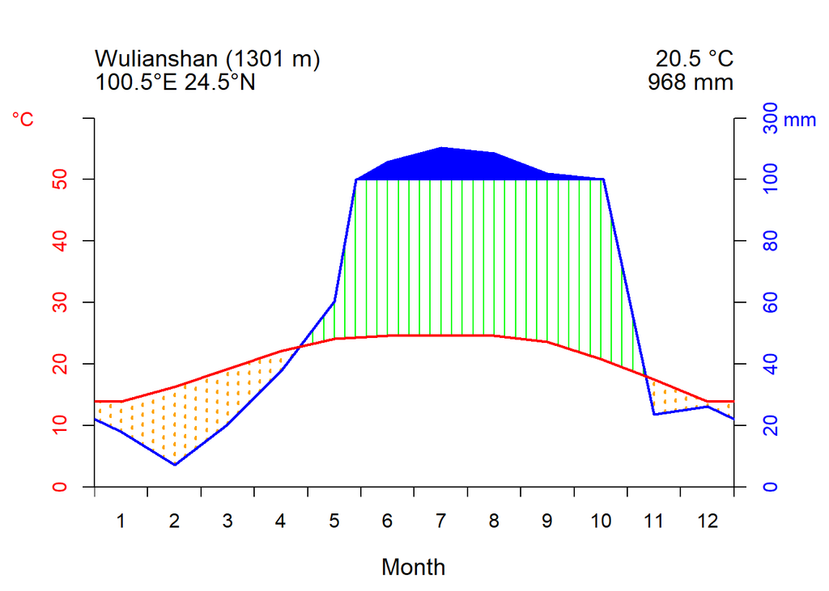

```r
data("plotdata")
loc <- subset(plotdata,No==2)
clim_plot(loc)
```

In the figure above:

- The red curve represents the annual variation of temperature, and blue one represents of precipitation variation. These two curves form two types of patches indicating humidity and aridity levels. The string-filled patches represent humid seasons while those with scattered points represent arid seasons. The polygon filled with the color same as precipitation curve indicates months with precipitation over 100mm, displaying the wet season period.
- The information on the left top includes the name, the altitude and the coordinates of the locations. The right top are the values of annual mean temperature and mean precipitation.

## Solution to plot for serveral location

`clim_plot`only supports constructing diagrams for one location at a time, as we recommend checking each plot individually, and importing multiple vectors of climate data increases the risk of errors. Therefore, if you require automated plotting for several locations, utilizing a loop is recommended:

```r
data("plotdata")
list <- unique(plotdata$No)
par(mfrow=c(1,1))
for (i in 1:5){
 k <- list[i]
sub <- subset(plotdata,No==k)
clim_plot(data=sub,ylabel = TRUE,
          ylab1="Temperature(\U{00B0}C)",
          ylab2="Precipitation(mm)",
           p50line = TRUE)
}
```

## Other tips of climatic diagram plotting

### Plotting the frosty months

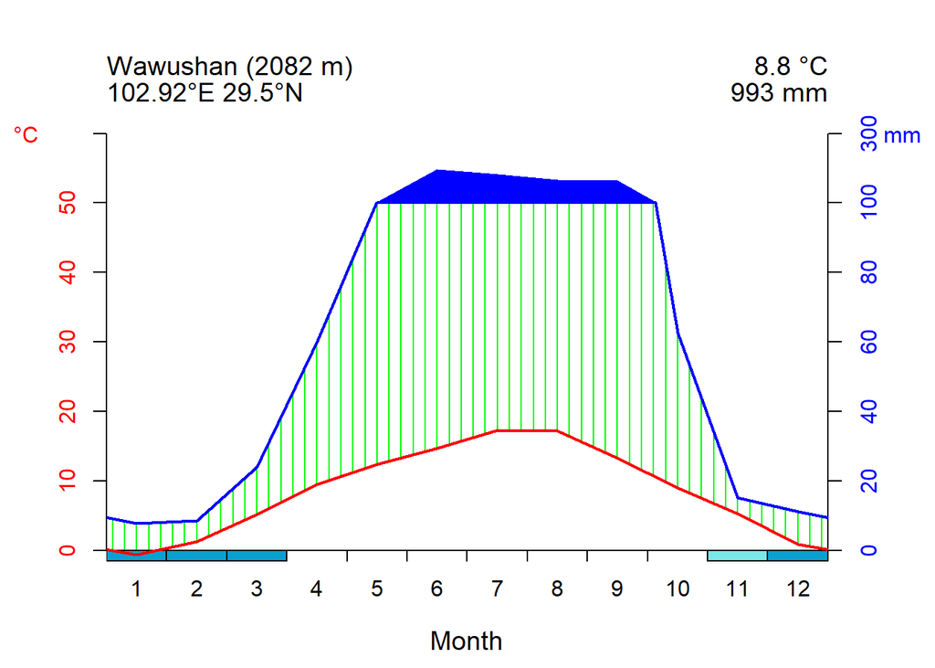

```r
data("plotdata_Frost")
loc <- subset(plotdata_Frost,No==3)
clim_plot(data=loc,ShowFrost = T)
```

The blocks with light blue color on x-axis represent the months with potential frost, and the dark blue ones mean those with confirmed frost.

### Color and axis modification

The color and the axis labels could be customized to meet specific requirements.

It is possible to adjust the colors of temperature, precipitation, humidity, aridity, wet season patches and frosty month blocks.

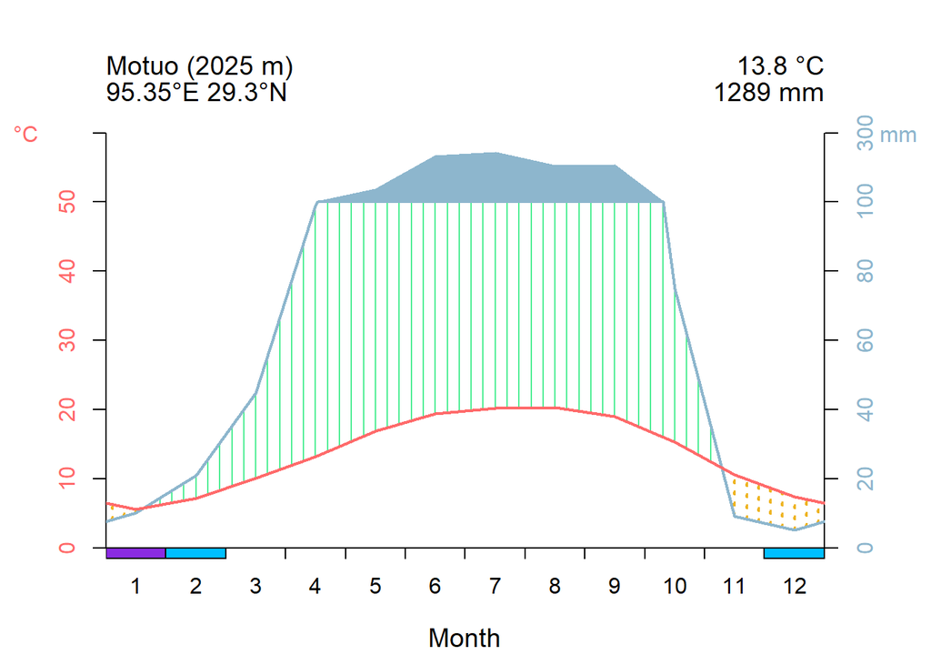

```r
loc <- subset(plotdata_Frost,No==1)
clim_plot(loc,pcol = "#8DB6CD",tcol = "#FF6A6A",wcol="#4EEE94",dcol = "#EEB422",pfcol="#00BFFF",sfcol="#8A2BE2",ShowFrost = TRUE)
```

Additionally, the display of axis labels can be controlled and custom labels can be imported using parameters `ylabel`, `ylab1`, `ylab2` `mlab` and `xlab` .

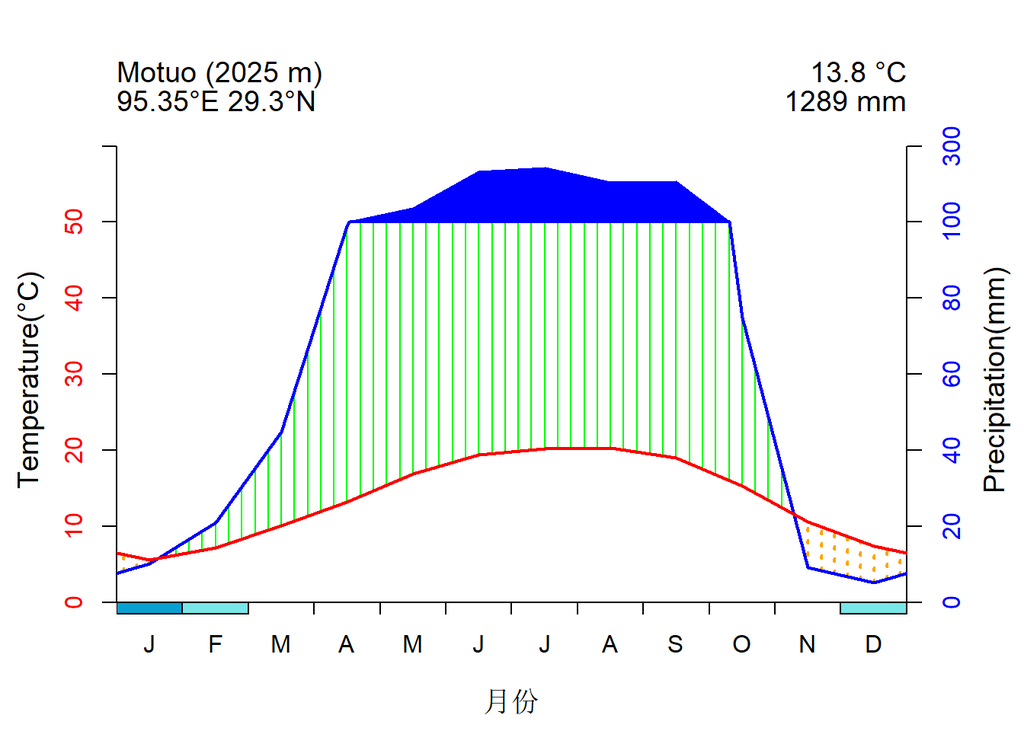

```r
loc <- subset(plotdata_Frost,No==1)
clim_plot(loc,xlab="月份",mlab = "en",ylabel = TRUE,ylab1 ="Temperature(\U{00B0}C)",ylab2 ="Precipitation(mm)",ShowFrost = TRUE)
```

### Auxiliary marker

Displaying extreme temperatures, the auxiliary line of precipitation curve and position of 50°C-100mm are optional.

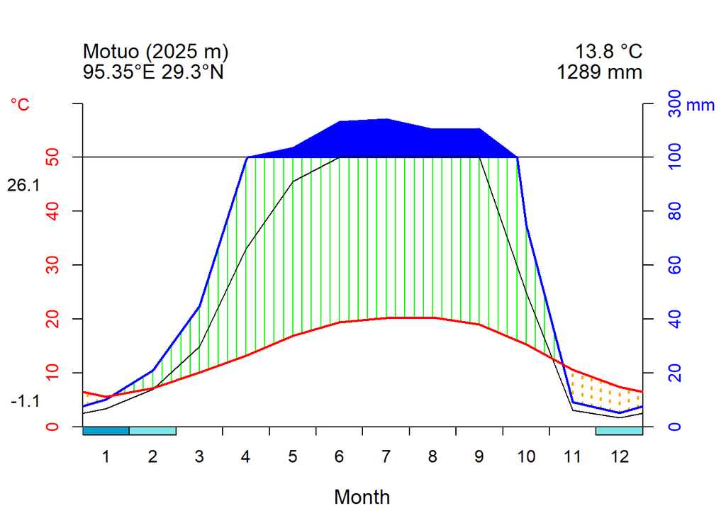

```r
loc <- subset(plotdata_Frost,No==1)
clim_plot(loc,p3line = TRUE,p50line = TRUE,extremeT = TRUE,ShowFrost = TRUE)
```

## Reference

1. Guijarro J A (2023). climatol: Climate Tools (Series Homogenization and Derived Products), 4.0.0., https://CRAN.R-project.org/package=climatol.
2. Fick, S.E. and R.J. Hijmans, (2017). WorldClim 2: new 1km spatial resolution climate surfaces for global land areas. International Journal of Climatology 37 (12): 4302-4315.
3. Harris, I., Osborn, T.J., Jones, P.D., Lister, D.H. (2020). Version 4 of the CRU TS monthly high-resolution gridded multivariate climate dataset. Scientific Data 7: 109.
4. Walter H & Lieth H (1960): Klimadiagramm Weltatlas. G. Fischer, Jena.